# DATA550_final_proj

Jiayi Liu

2025-05-02

# Introduction

The **Healthy People 2020 Tobacco Use Objectives** dataset, provided by the CDC, is part of a national initiative aimed at reducing tobacco consumption and its associated health risks in the United States. This report explores trends and key factors influencing progress toward meeting the objectives.

# Data Loading

We load the dataset from a local directory.

```r
library(tidyverse)
file_path <- "data/Healthy_People_2020_Tobacco_Use_Objectives_20250128.csv"
data <- readr::read_csv(file_path)
# Display first few rows
head(data)
```

```
## # A tibble: 6 × 16
##   `Topic Area` `Key Area`              `Objective Number` Leading Health Indic…¹
##   <chr>        <chr>                   <chr>              <chr>
## 1 Tobacco Use  Social and Environment… TU-13.17           <NA>
## 2 Tobacco Use  Social and Environment… TU-13.10           <NA>
## 3 Tobacco Use  Social and Environment… TU-11.3            <NA>
## 4 Tobacco Use  Tobacco Use Prevalence  TU-3.7             <NA>
## 5 Tobacco Use  Health Systems Changes  TU-10.3            <NA>
## 6 Tobacco Use  Tobacco Use Prevalence  TU-2.2             LHI: Leading Health I…
## # ℹ abbreviated name: ¹`Leading Health Indicator`
## # ℹ 12 more variables: Developmental <chr>, `Main Objective Text` <chr>,
## #   `Specific Objective Text` <chr>, Target <dbl>, Baseline <dbl>,
## #   Symbol <chr>, Units <chr>, `Baseline Statement` <chr>,
## #   `Baseline Year` <dbl>, TargetSettingMethodology <chr>, DataSource <chr>,
## #   `Objective Details` <chr>
```

# Exploratory Data Analysis

## Summary Statistics

We first examine the structure and summary of the dataset.

```r
# Structure of the dataset
str(data)
```

```
## spc_tbl_ [77 × 16] (S3: spec_tbl_df/tbl_df/tbl/data.frame)
##  $ Topic Area              : chr [1:77] "Tobacco Use" "Tobacco Use" "Tobacco Use" "Tobacco Use" ...
##  $ Key Area                : chr [1:77] "Social and Environmental Changes" "Social and Environmental Changes" "Social and Environmental Changes" "Tobacco Use Prevalence" ...
##  $ Objective Number        : chr [1:77] "TU-13.17" "TU-13.10" "TU-11.3" "TU-3.7" ...
##  $ Leading Health Indicator: chr [1:77] NA NA NA NA ...
##  $ Developmental           : chr [1:77] NA NA NA NA ...
##  $ Main Objective Text     : chr [1:77] "Establish laws in States, District of Columbia, Territories, and Tribes on smoke-free indoor air that prohibit "| __truncated__ "Establish laws in States, District of Columbia, Territories, and Tribes on smoke-free indoor air that prohibit "| __truncated__…
##  $ Specific Objective Text : chr [1:77] "Establish laws in States and the District of Columbia on smoke-free indoor air that prohibit smoking in College"| __truncated__ "Establish laws in States and the District of Columbia on smoke-free indoor air that prohibit smoking in Multiunit housing" "Red…
##  $ Target                  : num [1:77] 51 51 33.8 0.2 39.3 ...
##  $ Baseline                : num [1:77] 1 0 37.6 2.2 35.7 19.5 58.5 6.3 8.4 NA ...
##  $ Symbol                  : chr [1:77] NA NA "%" "%" ...
##  $ Units                   : chr [1:77] "States and D.C." "States and D.C." "Percent" "Percent" ...
##  $ Baseline Statement      : chr [1:77] "1 State had a smoke-free indoor air law prohibiting smoking on college and university campuses in 2009" "0 States or the District of Columbia had smoke-free indoor air laws that prohibit smoking in multiunit housing in 2009" "37.6 percent of nonsmoking adu…
##  $ Baseline Year           : num [1:77] 2009 2009 NA 2008 2010 ...
##  $ TargetSettingMethodology: chr [1:77] "Total coverage" "Total coverage" "10 percent improvement" "2 percentage point improvement" ...
##  $ DataSource              : chr [1:77] "Increase" "Increase" "Decrease" "Decrease" ...
##  $ Objective Details       : chr [1:77] "State Tobacco Activities Tracking and Evaluation System (STATE), CDC, NCCDPHP, OSH" "State Tobacco Activities Tracking and Evaluation System (STATE), CDC, NCCDPHP, OSH" "National Health and Nutrition Examination Survey (NHANES), CDC, NCHS" "National Survey…
##  - attr(*, "spec")=
##   .. cols(
##   ..   `Topic Area` = col_character(),
##   ..   `Key Area` = col_character(),
##   ..   `Objective Number` = col_character(),
##   ..   `Leading Health Indicator` = col_character(),
##   ..   Developmental = col_character(),
##   ..   `Main Objective Text` = col_character(),
##   ..   `Specific Objective Text` = col_character(),
##   ..   Target = col_double(),
##   ..   Baseline = col_double(),
##   ..   Symbol = col_character(),
##   ..   Units = col_character(),
##   ..   `Baseline Statement` = col_character(),
##   ..   `Baseline Year` = col_double(),
##   ..   TargetSettingMethodology = col_character(),
##   ..   DataSource = col_character(),
##   ..   `Objective Details` = col_character()
##   .. )
##  - attr(*, "problems")=<externalptr>
```

```r
# Summary statistics
summary(data)
```

```
##   Topic Area          Key Area         Objective Number
##  Length:77          Length:77          Length:77
##  Class :character   Class :character   Class :character
##  Mode  :character   Mode  :character   Mode  :character
##
##
##
##
##  Leading Health Indicator Developmental      Main Objective Text
##  Length:77                Length:77          Length:77
##  Class :character         Class :character   Class :character
##  Mode  :character         Mode  :character   Mode  :character
##
##
##
##
##  Specific Objective Text     Target           Baseline        Symbol
##  Length:77               Min.   :  0.000   Min.   : 0.00   Length:77
##  Class :character        1st Qu.:  8.675   1st Qu.: 6.00   Class :character
##  Mode  :character        Median : 51.000   Median :19.35   Mode  :character
##                          Mean   : 39.235   Mean   :25.54
##                          3rd Qu.: 51.000   3rd Qu.:37.70
##                          Max.   :100.000   Max.   :85.70
##                          NA's   :9         NA's   :9
##     Units           Baseline Statement Baseline Year  TargetSettingMethodology
##  Length:77          Length:77          Min.   :2005   Length:77
##  Class :character   Class :character   1st Qu.:2008   Class :character
##  Mode  :character   Mode  :character   Median :2009   Mode  :character
##                                        Mean   :2009
##                                        3rd Qu.:2009
##                                        Max.   :2015
##                                        NA's   :14
##   DataSource        Objective Details
##  Length:77          Length:77
##  Class :character   Class :character
##  Mode  :character   Mode  :character
##
##
##
##
```

## Data Cleaning

We check for missing values and handle them appropriately.

```r
# Count missing values
colSums(is.na(data))
```

```
##               Topic Area                 Key Area         Objective Number
##                        0                        0                        0
## Leading Health Indicator            Developmental      Main Objective Text
##                       74                       68                        0
##  Specific Objective Text                   Target                 Baseline
##                        0                        9                        9
##                   Symbol                    Units       Baseline Statement
##                       32                        0                        0
##            Baseline Year TargetSettingMethodology               DataSource
##                       14                        1                        9
##        Objective Details
##                        0
```

```r
data_clean <- data %>% filter(!(is.na(Target) & is.na(Baseline)))

nrow(data_clean) # > 0, proceed to visualization
```

```
## [1] 68
```

```r
# create a direct objective_status column
data_clean <- data_clean %>%
  mutate(Objective_Status = case_when(
    !is.na(Target) & !is.na(Baseline) & Baseline >= Target ~ "Achieved",
    !is.na(Target) & !is.na(Baseline) & Baseline < Target  ~ "In Progress",
    TRUE ~ "Unknown"
  ))

# check if this created meaningful categories
table(data_clean$Objective_Status)
```

```
##
##    Achieved In Progress
##          26          42
```

# Visualization

## Progress Toward Objectives

A bar plot shows the distribution of progress toward tobacco reduction objectives.

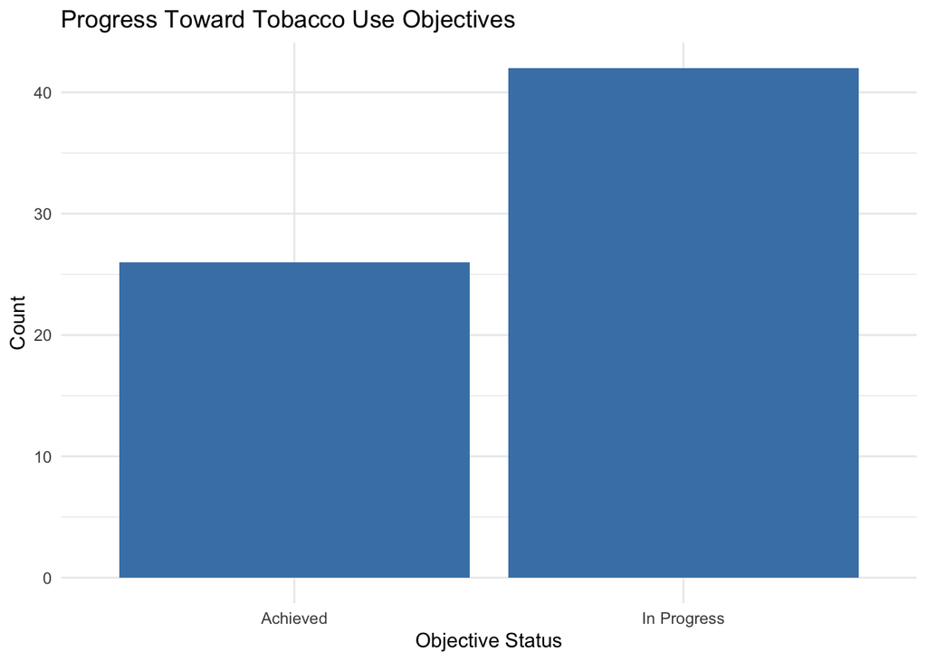

```r
ggplot(data_clean, aes(x = Objective_Status)) +
  geom_bar(fill = "steelblue") +
  labs(title = "Progress Toward Tobacco Use Objectives",
       x = "Objective Status",
       y = "Count") +
  theme_minimal()
```

**Figure 1**: The distribution of objectives based on their current status.

## Distribution of Baseline Tobacco Use Rates

A histogram showing the distribution of baseline rates.

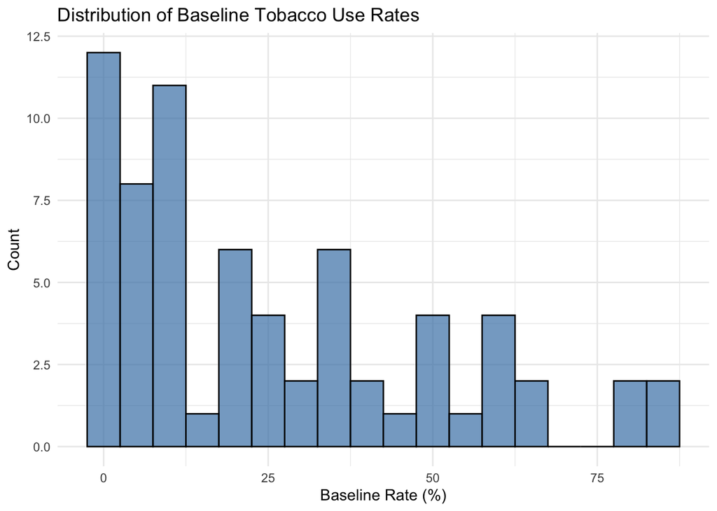

```r
ggplot(data_clean, aes(x = Baseline)) +
  geom_histogram(binwidth = 5, fill = "steelblue", color = "black", alpha = 0.7) +
  labs(title = "Distribution of Baseline Tobacco Use Rates",
       x = "Baseline Rate (%)",
       y = "Count") +
  theme_minimal()
```

## Baseline Tobacco Use Rates by Objective Status

A box plot comparing baseline rates for achieved vs. in-progress objectives.

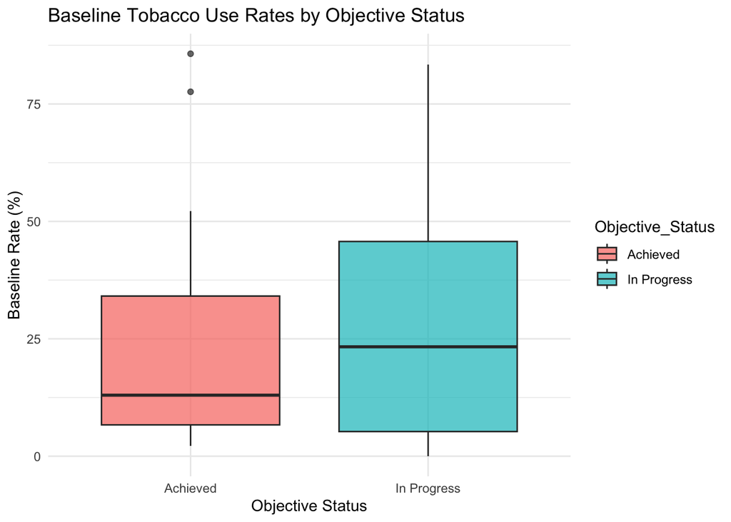

```r
ggplot(data_clean, aes(x = Objective_Status, y = Baseline, fill = Objective_Status)) +
  geom_boxplot(alpha = 0.7) +
  labs(title = "Baseline Tobacco Use Rates by Objective Status",
       x = "Objective Status",
       y = "Baseline Rate (%)") +
  theme_minimal()
```

## Proportion of Objectives by Status

A pie chart displaying the proportion of achieved vs. in-progress objectives.

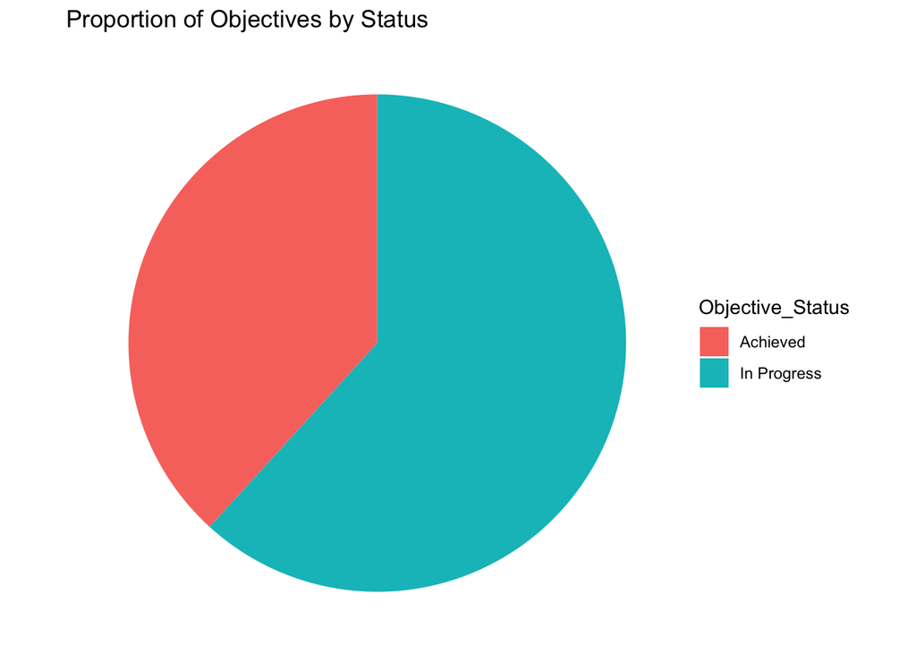

```r
data_pie <- data_clean %>%
  group_by(Objective_Status) %>%
  summarise(count = n())

ggplot(data_pie, aes(x = "", y = count, fill = Objective_Status)) +
  geom_bar(stat = "identity", width = 1) +
  coord_polar("y") +
  labs(title = "Proportion of Objectives by Status") +
  theme_void()
```

## Baseline vs. Target Tobacco Use Rates

A scatter plot comparing baseline values to target goals.

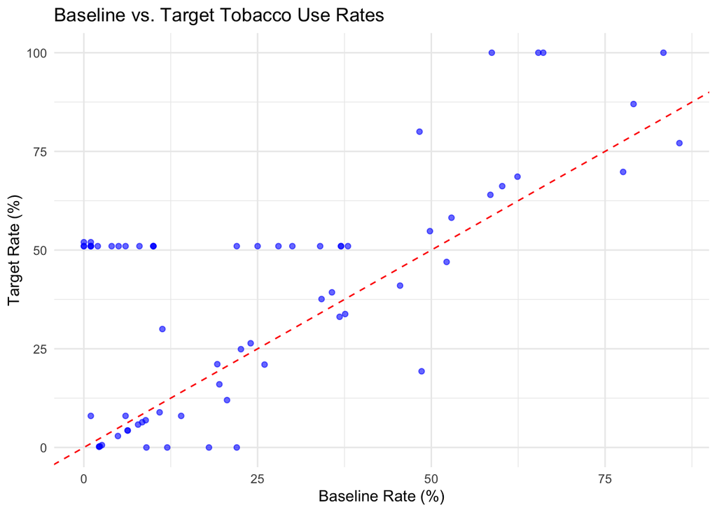

```r
ggplot(data_clean, aes(x = Baseline, y = Target)) +
  geom_point(color = "blue", alpha = 0.6) +
  geom_abline(slope = 1, intercept = 0, linetype = "dashed", color = "red") +
  labs(title = "Baseline vs. Target Tobacco Use Rates",
       x = "Baseline Rate (%)",
       y = "Target Rate (%)") +
  theme_minimal()
```

# Statistical Analysis

We use a simple linear regression model to assess factors influencing progress.

```r
lm_model <- lm(Baseline ~ Objective_Status, data = data_clean)
summary(lm_model)
```

```
##
## Call:
## lm(formula = Baseline ~ Objective_Status, data = data_clean)
##
## Residuals:
##     Min      1Q  Median      3Q     Max
## -27.352 -19.517  -5.052  14.388  63.088
##
## Coefficients:
##                             Estimate Std. Error t value Pr(>|t|)
## (Intercept)                   22.612      4.721   4.790 9.82e-06 ***
## Objective_StatusIn Progress    4.741      6.007   0.789    0.433
## ---
## Signif. codes:  0 '***' 0.001 '**' 0.01 '*' 0.05 '.' 0.1 ' ' 1
##
## Residual standard error: 24.07 on 66 degrees of freedom
## Multiple R-squared:  0.00935,    Adjusted R-squared:  -0.005659
## F-statistic: 0.623 on 1 and 66 DF,  p-value: 0.4328
```

# Conclusion and Recommendations

Based on the findings:

**Recommendations:** - Strengthen policies targeting lagging objectives.

- Enhance public awareness campaigns.
- Further research to identify barriers to progress.

This analysis provides valuable insights for future tobacco control strategies.